# web servers Q&A

陈颖珊

2019/5/15

#### 列举一些开源的云计算管理平台项目

OpenStack、Open vSwitch、Docker、Kubernetes #### 云服务提供商提供的服务器安全组有什么用？

安全组是一种虚拟的防火墙。在安全组内可以放行系统相应的端口号以及IP访问的权限(如设置只能某些IP才可访问此台服务器)等。安全组具有数据包过滤、状态检测等功能，可以设置一系列的安全组规则来允许或禁止安全组内的ECS实例对公网或私网的访问，同时也可限制外部网络对ECS服务器的访问

参考： [阿里云安全组](https://help.aliyun.com/document_detail/25387.html?source=5176.11533457&userCode=4phqzhon&type=copy) & [浅谈云服务器安全组功能以及使用](https://www.cnblogs.com/xu-yi/p/10447013.html)

#### 为什么阿里云在国内的市场占有率要远远超过其他的几家厂商？

最早（云梯计划），最稳定，最成熟，投入最大 #### HTML 是一种编程语言吗？ `HTML`全称是超文本标记语言(Hyper Text Markup Language)，因此它跟`Python`, `C++`, `JAVA`等不一样，不是传统意义上的编程语言，而是一种标记语言(markup language)。由浏览器负责对`html`进行编译和渲染。

#### HTML、CSS、JavaScript 三者之间的关系是什么？

一个网页的正常运行一般需要三个要素HTML/CSS/JavaScript,分别代表框架，样式和行为。框架主要设定网页的不同地方放置不同的元素。而这个位置的内容以什么字体，什么颜色来显示就是样式。最后，这个位置的内容要传到后台的什么字段就是行为。

看过一个很有趣的比喻，假如整个网站是一个人的身体/那么HTML 是人的躯壳，CSS是人的五官和皮肤，JavaScript则是驱动整个人体活动的神经系统。 #### 简述 HTML、XHTML 和 XML的异同 `HTML`超文本标记语言是标准通用标记语言下的一个应用，也是一种规范，一种标准。

`XML`(Extensible Markup Language)，可扩展标记语言。XML是标准通用标记语言的子集，是一种用于标记电子文件使其具有结构性的标记语言，它被设计用来传输和存储数据，是对超文本标记语言的补充。 XHTML`(Extensible HyperText Markup Language)，可扩展超文本标记语言。XHTML基于可扩展标记语言（XML）。XHTML就是一个扮演着类似HTML的角色的可扩展标记语言（XML），所以，本质上说，XHTML是一个过渡技术，结合了部分XML的强大功能及大多数HTML的简单特性,编码更加严谨。 #### 什么是 DOM? DOM是文档对象模型(Document Object Model)的缩写，它是 HTML 文档的对象表示，同时也是 HTML 元素面向外部(如Javascript)的接口。

应用程序不是直接对`HTML`文档进行操作的，而是首先由浏览器对 html 文档进行分析。然后，应用程序通过浏览器所提供的 DOM 接口对分析结果进行操作，从而间接地实现了对 HTML 文档的访问。

DOM定义了HTML文档的**逻辑结构**，给出了一种访问和处理这两种文档的方法。 当服务器把html文件发送给浏览器的时候，浏览器会先读取出这个html文件的DOM树:

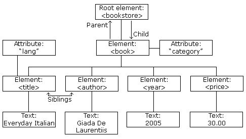

dom tree

在[知乎](https://www.zhihu.com/question/34219998/answer/133487045)上看到一个比较有趣的比喻：

```
@破壁人王涛
    如果将文档的内容视为一栋办公楼，那DOM就是一种对办公楼内空间分配的标准，它规定了，这个办公楼的空间，应该是先分楼层，再分房间的方式，方便访客找到这个房间。有什么用？

    举例说明：你要去一个叫201的房间（获取对象），你怎么去呢? 用DOM的方法，你只需要走到二层，然后到第一个房间就行了，而你是用走，爬，甚至跳舞的方式过去（即：使用不同的编程语言）都没关系，你只要按照DOM的规定，最终都能找到这个房间。

    全世界的房子都是分楼层，再分房间的结构，于是，你去哪个办公楼找人，你都能通过上某个楼层、按照房间的排列顺序去找到某个房间。

    同理全世界的网页内容都是DOM的结构，于是，你去找网页中的某个对象时，都能通过某个标签的某个子标签找到某个对象。
```

#### 现在的网页 HTML 文件一般会包含哪些 HTML 标签？

`<html></html>` `<head></head>` `<meta></meta>`

`<body></body>` `<table></table>` `<tr></tr>` `<td></td>` `<li></li>` `<a></a>` `<link>`(开放标签) `<script></script>` `<style></style>`

…

[参考手册](https://www.runoob.com/tags/html-reference.html)

#### 列举几个 HTML 中常见的开放式标签

`<img>` `<input>` `<meta>`

#### CSS 选择器有哪些？

CSS选择器用于选择你想要的元素的样式的模式。HTML页面中的元素就是通过CSS选择器进行控制的。

每一条css样式定义由两部分组成，`选择器{样式}`。 “选择器”指明了`{}`中的“样式”的作用对象，也就是“样式”作用于网页中的哪些元素。CSS选择器大致分为：

- 类选择器: `.class`
- id选择器: `#id`
- 标签选择器
- 元素选择器
- 后代选择器
- 子元素选择器

更多参考：[CSS选择器参考手册](http://www.w3school.com.cn/cssref/css_selectors.asp) #### Chrome，Safri，Firefox 如何查看网页源代码并快速定位元素？快捷键是什么？ 大部分浏览器按`F12`就可以调出开发页面， `Ctrl+U`可以打开页面源代码 #### 有哪些常用的 Chrome 插件可以用于网页服务开发调试？ `postman`:可以调试简单的css、html、脚本等简单的网页基本信息，还可以发送几乎所有类型的HTTP请求。 官方文档 [postman](https://www.getpostman.com/docs/v6/)

`Chrome Dev Tools`:Chrome本身的Chrome DevTools就是一个很好的开发调试工具。更多使用方法可以看：[你不知道的Chrome DevTools](https://segmentfault.com/a/1190000000494090) #### 目前常见的前端框架有哪些？分别罗列一些使用这些框架的生物信息学数据库/网页服务 #### HTML 元素和 Markdown 之间的对应关系 语法种类很少，只对应 HTML 标记的一小部分 块级HTML元素内是不能使用Markdown语法 #### document.getElementById 是用来做什么的？ HTML DOM 定义了多种查找元素的方法,当你需要查找文档中的一个特定的元素，`getElementById()` 可返回对拥有指定 ID 的第一个对象的引用。所以在操作文档的一个特定的元素时，最好给该元素一个 id 属性，为它指定一个（在文档中）**唯一**的名称，然后就可以用该 ID 查找想要的元素。

参考：[HTML DOM getElementById() 方法](http://www.w3school.com.cn/jsref/met_doc_getelementbyid.asp) #### JavaScript 的运行速度和 Python/R 相比是快还是慢？ javacript > pyhon > R

（可以用斐波那契数列验证） #### Cookie 和 Session 存在的目的是什么？ 一般而言是为了让用户保持登录状态。 客户端（用户）第一次访问一个服务器时，服务器会生成一个**Cookie**和**Session**。前者保存在客户端浏览器中，后者保存在服务器中，session比cookie更安全。下一次这个客户端再访问这个服务器时，服务端通过携带的Cookie找出该用户信息。服务端就能够知道是谁访问了。(p.s. `Session` 是对服务端来说的, 客户端没有 Session 这一说)。

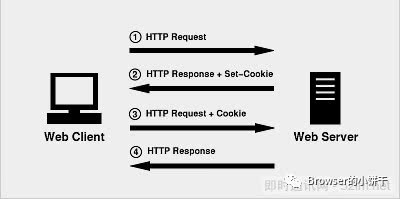

#### 什么是 token 验证？

在非Web的情况下, 没有Cookie的时候,一般用`token`解决用户身份认证问题。

`Token` 通常叫**令牌**, 最简单的Token组成 `uid`(用户唯一身份标识),`time`(时间戳),`sign`(签名),还可以把不变的参数也放进token,避免多次查库。

[Cookie，Session和Token概念的正确理解](https://cloud.tencent.com/developer/news/247610)

#### JavaScript 数据有哪些类型？它和 R/Python 的数据类型是否有什么对应关系？

```
JavaScript的数据类型分为两大类，基本数据类型和复杂数据类型。
```

- 基本数据类型：Null、Undefined、Number，String，Boolean。
- 复杂数据类型：Object。

#### 如何设置多个 git 远程仓库，并分别推送和拉取？

使用命令 `git remote add <name> <url>`

`name` 表示你要给这个远程库起的名字 `url` 表示这个库的地址

提交：`git push <name> <branch>`

```bash
#添加第一个仓库
git remote add repo1 <仓库地址>
#添加第二个仓库
git remote add repo2 <仓库地址>
#提交到repo2
git push repo2 master(分支名)
#从repo2更新
git pull repo2 master
```

#### GitHub 克隆仓库时选择 git:// 和 https://的差异

https方式：通过填写账号和密码就可以clone代码库，但是缺点是每次fetch和push代码都需要输入账号和密码。

git://方式 ：是通过 ssh 密钥方式，要添加公钥 (ssh key)。ssh 默认是每次 fetch 和 push 代码都不需要输入账号和密码。

```bash
ssh-keygen -t rsa   #制作密钥
```

#### 什么是持续集成？

持续集成指的是，频繁地（一天多次）将代码集成到主干。

参考资料： [什么是持续集成](http://www.ruanyifeng.com/blog/2015/09/continuous-integration.html) #### 什么是敏捷开发？ #### (unfinished)GitHub 仓库可以关联哪些第三方网页服务进行发布前的自动测试？ #### (unfinished)GitHub 的 Webhook 可以用来做什么？ #### MySQL 的开源版本叫什么？它和甲骨文公司维护的版本有什么区别？ **`MySQL Community Server`** 是开源免费的，这也是我们通常用的 MySQL 的版本;

MySQL 和Oracle 都是流行的关系数据库管理系统。后者是收费的。Oracle的SQL语法与MySQL有很大不同。Oracle为称为PL / SQL的编程语言提供了更大的灵活性。与Oracle相比，MySQL没有表空间，角色管理，快照，同义词和包以及自动存储管理。

还有其余更多区别：[mysql和oracle的区别有哪些](https://baijiahao.baidu.com/s?id=1626781011360393366&wfr=spider&for=pc)

#### MySQL 和 SQLite 分别适用于哪些网页应用程序？

SQLITE功能简约，小型化，追求最大磁盘效率；（一般用于客户端开发）

MYSQL功能全面，综合化，追求最大并发效率。

如果只是单机上用的，数据量不是很大，需要方便移植或者需要频繁读/写磁盘文件的话，就用SQLite比较合适；如果是要满足多用户同时访问，或者是网站访问量比较大是使用MYSQL比较合适。 #### (unfinished)SQLite 数据库能否设置用户名和密码？ #### (unfinished)在 R/Python 中提供SQLite 和 MySQL 接口的包/模块分别是？ #### HTML与HTML5的区别是？目前常用哪个？ 与传统HTML相比，HTML5新增了很多元素特性，并且简化了一些语法。

目前由于HTML5的标准还未完全定型，加之部分浏览器还不支持html5的新特性，考虑到兼容性问题，html还是最常用的。 #### 什么是前端开发？什么是后端开发？两者有什么区别？ 负责对服务器运算写脚本的称为后端开；负责对更贴近用户的浏览器或客户端运算编程的称为前端开发；

服务器脚本(后端)： `PHP、ASP.NET`

浏览器脚本(前端)： `HTML、CSS、JavaScript`

#### Rstudio Server算云服务器吗？是不是可以看作为一台只能可视化使用Rstudio的服务器？

`RStudio Server`是一个基于 web 访问的`RStudio云端开发环境`，需要安装在服务器上，支持多用户远程访问使用。简单来说，`RStudio Server` 是一个 Linux 服务器上的**应用程序**，提供了在服务器上运行的 R 环境，而用户通过浏览器来访问。 #### (unfinished)类似于MySQL 关系型数据库管理系统有哪些？相比而言，MySQL 最主要的优点在哪？ #### 浏览器，服务器和数据库之间的关系是什么，用户在浏览器中输入一个网址后这三者是怎样工作的? 当用户在浏览器中输入一个网址，也就是通过http协议向服务器发出请求。服务器会对相应请求作出响应，从数据库中调取数据，再将html内容返回给浏览器，这时浏览器就会解析html，将结果呈现给用户。

#### 云计算中的 laas,Paas,Saas 分别指的是什么，是通过什么来划分的。

IaaS, PaaS和SaaS是云计算的三种服务模式。

`SaaS`：`Software-as-a-Service`（软件即服务）提供给客户的服务是运营商运行在云计算基础设施上的应用程序，用户可以在各种设备上通过客户端界面访问，如浏览器。

`PaaS`：`Platform-as-a-Service`（平台即服务）提供给消费者的服务是把客户采用提供的开发语言和工具（例如Java，python, .Net等）开发的或收购的应用程序部署到供应商的云计算基础设施上去。

`IaaS`： `Infrastructure-as-a-Service`（基础设施即服务）提供给消费者的服务是对所有计算基础设施的利用，包括处理CPU、内存、存储、网络和其它基本的计算资源，用户能够部署和运行任意软件，包括操作系统和应用程序。

### 编程题

#### (unfinished)使用最基础的 HTML/CSS/JavaScript 语法，设计一个简单的单页网页界面（至少应该包含一二三级标题和正文、表格、内容分栏、超链接、图片、视频、点击动画等）

暂时列出所用到的相关标签

```html
<!doctype html>
<html>
<head>
  <meta>
  <meta>
  <title></title>
</head>
<body>
  <h1></h1>
  <h2></h2>
  <h3></h3>
<!--段落-->
  <div>
    <p><a href="www.baidu.com">网速测试</a></p>
    <img src="/test.jpg" alt="just for test">
  </div>
<!--表格-->
  <div>
    <table>
      <tr>
        <td></td>
        <td></td>
      </tr>
      <tr>
        <td></td>
        <td></td>
      </tr>
    </table>
  </div>
</body>
</html>
```

#### 使用 JavaScript 编写一个可以生成斐波那锲数列的函数，输入为n，表示该数列所包含的数字个数

```
斐波那契数列(Fibonacci)也叫兔子数列。
在第一个月有一对刚出生的小兔子，在第二个月小兔子变成大兔子并开始怀孕，
第三个月大兔子会生下一对小兔子，并且以后每个月都会生下一对小兔子。
如果每对兔子都经历这样的出生、成熟、生育的过程，并且兔子永远不死，
那么兔子的总数是如何变化的？
```

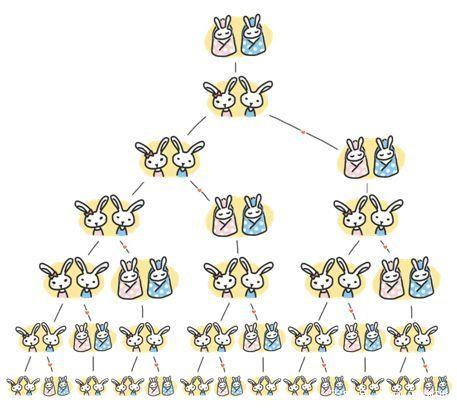

兔子问题

其实是一个**数列问题**，根据列出下表：

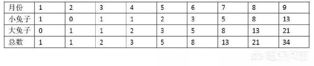

我们可以得到两个信息： 1. 从3个月（n=3)开始，小兔子的数量跟前一个月(n=2)大兔子的数量是一致的。 2. 从3个月（n=3)开始，大兔子的数量是前一个月(n=2)大兔子和小兔子的总和。

```
按照这个表格，我们会发现无论是小兔子对数、大兔子对数还是总对数，
除了最初几个数字不一样之外，
后面都是按照1、1、2、3、5、8、13…变化的。
个数列就称为兔子数列或者斐波那契数列。
兔子数列最大的特点就是前两项之和等于后一项
```

用an表示一个数列的第n项，那么斐波那契数列的规律就是:

**a<sub>1</sub>=1**

**a<sub>2</sub>=1**

**a<sub>n+2</sub> = a<sub>n</sub>+a<sub>n+1</sub>**

或者是

n=0, f(n)=0

n=1, f(n)=1

n>=1, f(n)=f(n-1)+f(n-2)

这是一种递归函数。 用Javascript实现斐波那契数列：

```javascript
function Fibonacci(n) {
  if (n==0){return 0}
  if (n==1){return 1}
  if (n>=1){
    return Fibonacci(n-1)+Fibonacci(n-2) }
}
```

参考：[什么是斐波那契数列](https://baijiahao.baidu.com/s?id=1606651492697783298&wfr=spider&for=pc)

#### (unfinished)比较相同功能的函数在JavaScript，R，和 Python 之间的差别（语法+速度）

可以用斐波那契数列来验证

#### 尝试本地部署 Gitlab 服务

Gitlab 是一个代码仓库管理系统，可以很方便的管理权限、代码review，创建、管理project。你可以用gitlab自己搭建一个类似于Github一样的系统，一般用于在企业、学校等内部网络搭建git私服。

参考资料：

[在本地服务器搭建gitlab仓库管理](https://www.cnblogs.com/nulige/p/6825625.html)

[手把手教你 GitLab 的安装及使用](https://www.jianshu.com/p/b04356e014fa)

```
Gitlab 相当于一个小型的 Github : GitLab可以实现一个**自托管**的Git项目仓库，可通过 Web 界面进行访问公开的或者私人项目。
它拥有与Github类似的功能可以管理团队对仓库的访问，它非常易于浏览提交过的版本并提供一个文件历史库。
```

##### 在CentOS7服务器中搭建 GitLab

###### 下载相关的包

```bash
yum install curl openssh-server openssh-clients postfix cronie policycoreutils-python –y    #安装 gitlab 依赖的包
```

###### 设置开机postfix的启动

```bash
systemctl start postfix

systemctl enable postfix
```

###### 防火墙设置

```bash
yum install firewalld systemd -y
service firewalld  start    #打开防火墙
sudo firewall-cmd --permanent --add-service=http
sudo systemctl reload firewalld   #设置并重启
```

###### 下载 GitLab

```bash
wget https://mirrors.tuna.tsinghua.edu.cn/gitlab-ce/yum/el7/gitlab-ce-8.6.7-ce.0.el7.x86_64.rpm #获取安装包

rpm -ivh gitlab-ce-8.6.7-ce.0.el7.x86_64.rpm  # 获取 rpm 包
```

###### 修改配置文件中的 ip 地址

```bash
vim /etc/gitlab/gitlab.rb #打开配置文件
external_url 'http://101.132.168.000' #输入你的ip地址，这里我输入的是服务器的ip
gitlab-ctl reconfigured
```

然后会出现一系列提示

```
Running handlers:
Running handlers complete
Chef Client finished, 220/307 resources updated in 01 minutes 26 seconds
gitlab Reconfigured!
```

重启 gitlab

```bash
gitlab-ctl restart
```

会出现提示

```
ok: run: gitlab-workhorse: (pid 13653) 1s
ok: run: logrotate: (pid 13661) 0s
ok: run: nginx: (pid 13667) 1s
ok: run: postgresql: (pid 13675) 0s
ok: run: redis: (pid 13683) 1s
ok: run: sidekiq: (pid 13688) 0s
ok: run: unicorn: (pid 13695) 0s
```

###### 在浏览器中访问 GitLab

打开浏览器输入网址：

[figure not shown]

修改密码后登陆

###### 新增一个仓库

[figure not shown]

###### 添加密钥

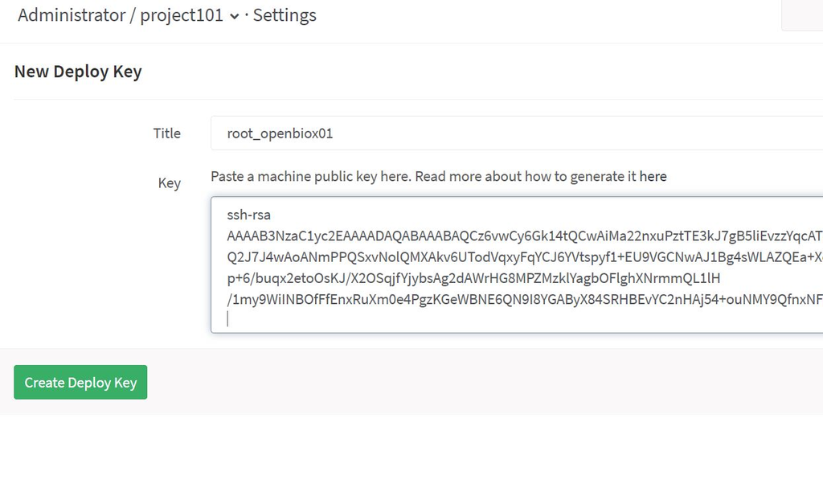

添加公钥之后克隆仓库

```bash
git clone git@101.132.168.150:root/project101.git
Cloning into 'project101'...
remote: Counting objects: 6, done.
remote: Compressing objects: 100% (3/3), done.
remote: Total 6 (delta 0), reused 0 (delta 0)
Receiving objects: 100% (6/6), done.
```

#### (unfinished)使用 MySQL 数据库创建一个用于存储用户信息的数据表：包含 username, email, password 三个字段，并分别使用 SQL 和 Python/R 客户端插入、删除和更新一行数据，密码使用 SHA256 进行加密